# Seminar Kolokium

Faktor-Faktor yang Berhubungan dengan Kepatuhan Pengobatan pada Penderita Filariasis di Indonesia:  
Analisis Data SKI 2023

Muhammad Ilham Basgoro

2521211014

Dosen Pembimbing

1. Prof. Dr. Masrizal, SKM., M.Biomed

2. Randy Novirsa, SKM., MKM., Ph.D

Dosen Penguji

1. Ade Suzana Eka Putri, SKM., M. CommHealth. Sc., Ph. D

2. Dr. Dra. Sri Siswati, SH., Apt., M. Kes

3. Ratno Widoyo, SKM., MKM., Ph.D

# Pendahuluan

## Latar Belakang

**Definisi:**  
Filariasis adalah penyakit menular kronis akibat infeksi cacing filaria.

**Penyebab:**  
cacing filaria berupa *W. bancrofti*, *Brugia malayi*, dan *Brugia timori*.

**Epidemiologi Deskriptif:**  
Dapat menyerang semua kelompok umur, dapat menyerang laki-laki maupun perempuan, dan umumnya ditemukan di wilayah tropis.

**Dampak:**  
Kecacatan, kemiskinan, dan stigma sosial.

**Solusi Utama:**  
Eliminasi filariasis dengan melaksanakan dua program utama yaitu Pemberian Obat Pencegahan Massal (POPM) dan penanganan kasus filariasis kronis di fasilitas kesehatan.

Selain itu, pemanfaatan data hasil Survei Kesehatan Indonesia tahun 2023 juga dapat membantu Indonesia dalam mencapai eliminasi filariasis.

## Situasi Filariasis

**Global:**  
Pada tahun 2023, sebanyak 657 juta orang di 39 negara memerlukan pemberian obat filariasis secara massal. Diperkirakan terdapat 25 juta orang yang terkena filariasis dengan hidrokel dan lebih dari 15 juta yang mengalami limfedema.

**Indonesia:**  
Jumlah kasus filariasis di Indonesia dari tahun 2020 – 2024

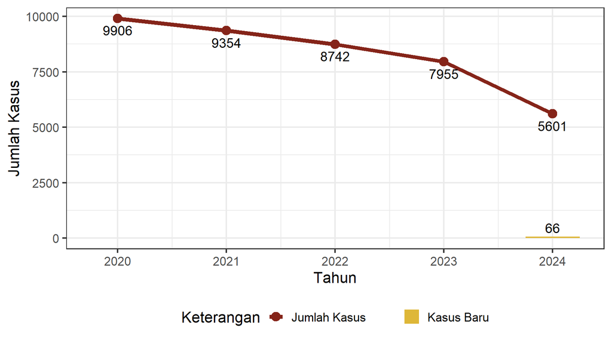

## Target Indonesia

- Indonesia telah menargetkan eliminasi filariasis pada tahun 2030.
  - Sejalan dengan *Roadmap* penyakit tropis terabaikan (*Neglected Tropical Diseases*/NTDs) yang diluncurkan oleh *World Health Organization* (WHO) untuk periode 2021 – 2030.
  - Sejalan dengan target *Sustainable Development Goals* (SDGs) nomor 3 Kehidupan Sehat dan Sejahtera, yaitu pada tahun 2030 mengakhiri epidemi penyakit tropis terabaikan.

Dalam mencapai eliminasi filariasis, Indonesia harus menurunkan angka mikrofilaria menjadi <1% di seluruh kabupaten/kota endemis.

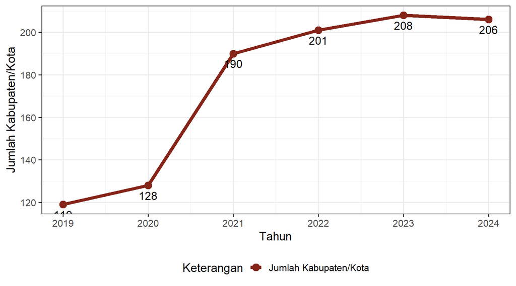

- Sampai 2021 proses penurunan mikrofilaria <1% menunjukkan peningkatan yang signifikan.
- Pada periode 2022 – 2024 proses penurunan mikrofilaria menunjukkan proses yang melambat, kondisi tersebut menunjukkan bahwa Indonesia belum *on the track* dalam mencapai eliminasi filariasis pada 2030.

Dalam upaya menurunkan mikrofilaria menjadi <1%, Indonesia melaksanakan kegiatan POPM filariasis pada seluruh penduduk di daerah endemis dengan cakupan minimal yang harus dicapai sebesar 65%.

Hingga tahun 2024, cakupan POPM filariasis di Indonesia menunjukkan kecenderungan menurun sejak tahun 2019.

Cakupan POPM filariasis di Indonesia dari tahun 2019 – 2024

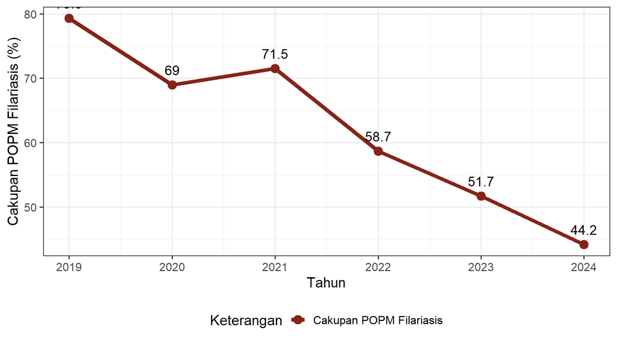

Penurunan cakupan POPM tersebut juga diikuti dengan penurunan tingkat kepatuhan pengobatan pada penderita filariasis di Indonesia.

- Studi yang dilakukan oleh Ipa dkk. di Indonesia menggunakan data Riskesdas 2018 menunjukkan bahwa tingkat kepatuhan pengobatan penderita filariasis di Indonesia sebesar 70%.
- Berdasarkan hasil SKI 2023, kepatuhan pengobatan penderita filariasis di Indonesia adalah 33%.

**Kepatuhan selama pengobatan merupakan faktor utama yang menentukan efektivitas pengobatan.**

WHO melalui teori *Adherence to long-term therapies* menjelaskan terdapat 5 dimensi yang dapat mempengaruhi kepatuhan pengobatan.  
1. *social and economic factors*.  
2. *health care team and system-related factors*.  
3. *condition-related factors*.  
4. *therapy-related factors*.  
5. *patient-related factors*.

Studi yang dilakukan oleh Ipa dkk. diketahui pada *dimensi social and economic factors* terdapat.  
1. Umur (AOR = 0,78; 95%CI = 0,77 – 0,79)  
2. Jenis kelamin (AOR = 1,02; 95%CI = 1,01 – 1,03)  
3. tingkat pendidikan (AOR = 1,35; 95%CI = 1,33 – 1,38)  
4. pekerjaan (AOR = 1,25; 95%CI = 1,23 – 1,26)  
5. status pernikahan (AOR = 0,93; 95%CI = 0,91 – 0,94)  
6. sosial ekonomi (AOR = 1,25; 95%CI = 1,23 – 1,27)  
7. status tempat tinggal (AOR = 0,82; 95%CI = 0,81 – 0,83)

Pada dimensi *condition-related factors* terdapat variabel status komorbid juga memiliki hubungan yang signifikan.

Berbeda dengan studi lain oleh Kesuma dkk. dengan variabel pada dimensi yang sama dimana status tempat tinggal tidak memiliki hubungan dengan kepatuhan penderita filariasis dalam mengonsumsi obat (AOR = 0,99; 95%CI = 0,96 – 1,0).

Studi Ipa dkk. yang menggunakan data Riskesdas 2018 belum memuat informasi mengenai alasan penderita filariasis tidak minum obat. Namun, pada SKI 2023 tersedia pertanyaan baru berupa Alasan UTAMA individu tidak minum obat sebagian atau seluruhnya.

**Rumusan Masalah**

Apa saja faktor-faktor yang berhubungan dengan kepatuhan pengobatan pada penderita filariasis di Indonesia?

## Tujuan Penelitian

### Tujuan Umum

Untuk mengetahui faktor-faktor yang berhubungan dengan kepatuhan pengobatan pada penderita filariasis di Indonesia.

### Tujuan Khusus

1. Mengetahui distribusi dan frekuensi kepatuhan pengobatan penderita filariasis, karakteristik responden (umur, jenis kelamin, status pernikahan, tingkat pendidikan, status pekerjaan, status diabetes, status wilayah, dan alasan tidak minum obat) di Indonesia berdasarkan hasil SKI 2023.
2. Mengetahui sebaran tingkat kepatuhan pengobatan penderita filariasis per provinsi di Indonesia berdasarkan hasil SKI 2023.
3. Mengetahui hubungan umur, jenis kelamin, status pernikahan, tingkat pendidikan, status pekerjaan, status diabetes, status wilayah, dan alasan tidak minum obat dengan kepatuhan pengobatan penderita filariasis di Indonesia berdasarkan hasil SKI 2023.
4. Mengetahui faktor dominan yang mempengaruhi kepatuhan pengobatan penderita filariasis di Indonesia berdasarkan hasil SKI 2023.

## Manfaat Penelitian

**Manfaat Teoritis:**  
Sebagai sumber informasi dan memperkaya pemahaman terkait faktor-faktor yang berhubungan dengan kepatuhan pengobatan filariasis di Indonesia.

**Manfaat Akademis:**  
Dapat memberikan kontribusi sebagai sumber pengetahuan dan materi pembelajaran, serta penerapan ilmu epidemiologi.

**Manfaat Praktis:**  
1. Bagi Pemerintah  
Dapat menjadi acuan dalam pengambilan keputusan untuk merumuskan kebijakan, khususnya terkait upaya pencegahan dan pengendalian filariasis di Indonesia.  
2. Bagi Fakultas Kesehatan Masyarakat  
sebagai referensi dan sumber informasi untuk mendukung pengembangan studi lebih lanjut.  
3. Bagi Peneliti Selanjutnya  
dapat menjadi salah satu referensi dalam mendukung pembaruan penelitian.

## Ruang Lingkup Penelitian

Penelitian ini membahas faktor-faktor yang berhubungan dengan kepatuhan pengobatan pada penderita filariasis di Indonesia merupakan penelitian kuantitatif dengan desain studi *cross sectional*. Data yang digunakan merupakan data sekunder dari Survei Kesehatan Indonesia tahun 2023. Terdapat 8 variabel independen dan 1 variabel dependen. analisis yang akan dilakukan mencakup analisis univariat, bivariat, dan multivariat, serta pemetaan.

# Tinjauan Pustaka

## Tinjauan Pustaka

**A. Filariasis**  
1. Definisi  
2. Epidemiologi  
3. Etiologi  
4. Penularan  
5. Masa inkubasi  
6. Gejala  
7. Diagnosis  
8. Vektor  
9. Pencegahan  
10. Pengobatan

**B. Kepatuhan Pengobatan**  
**C. Faktor yang Berhubungan dengan Kepatuhan Berobat Filariasis**  
**D. SKI 2023**

## Kerangka Teori

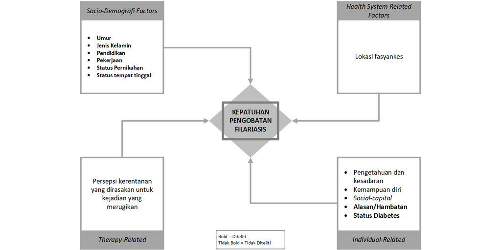

Kerangka Teori Faktor-Faktor yang Berhubungan Kepatuhan Pengobatan pada Penderita Filariasis dengan Modifikasi  
*Sumber: Adaptasi teori Adherence to long-term therapies WHO dan Titaley dkk.*

## Kerangka Konsep

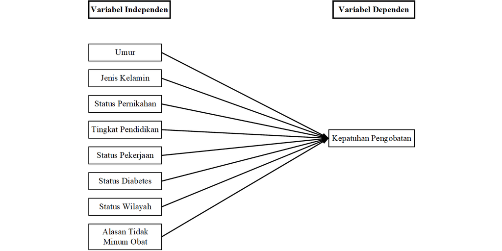

Kerangka Konsep Penelitian Faktor-Faktor yang Berhubungan dengan Kepatuhan Pengobatan Penderita Filariasis di Indonesia

## Hipotesis

1. Terdapat hubungan antara umur dengan kepatuhan pengobatan penderita filariasis di Indonesia berdasarkan hasil SKI 2023.
2. Terdapat hubungan antara jenis kelamin dengan kepatuhan pengobatan penderita filariasis di Indonesia berdasarkan hasil SKI 2023.
3. Terdapat hubungan antara status pernikahan dengan kepatuhan pengobatan penderita filariasis di Indonesia berdasarkan SKI 2023.
4. Terdapat hubungan antara tingkat pendidikan dengan kepatuhan pengobatan penderita filariasis di Indonesia berdasarkan hasil SKI 2023.
5. Terdapat hubungan antara status pekerjaan dengan kepatuhan pengobatan penderita filariasis di Indonesia berdasarkan hasil SKI 2023.
6. Terdapat hubungan antara status diabetes dengan kepatuhan pengobatan penderita filariasis di Indonesia berdasarkan hasil SKI 2023.
7. Terdapat hubungan antara status wilayah dengan kepatuhan pengobatan penderita filariasis di Indonesia berdasarkan hasil SKI 2023.
8. Terdapat hubungan antara alasan tidak minum obat dengan kepatuhan pengobatan penderita filariasis di Indonesia berdasarkan hasil SKI 2023.

# Metodologi Penelitian

**Jenis Penelitian:**  
Penelitian kuantitatif dengan desain studi *cross sectional*.

**Waktu dan Tempat:**  
Waktu: Januari - Maret Tahun 2026.  
Tempat: Indonesia.

**Populasi dan Sampel:**  
1. Populasi penelitian mencakup seluruh individu di Indonesia.  
2. Sampel penelitian terdiri 515 individu.

## Definisi Operasional

[output not shown]

# Definisi Operasional

[output not shown]

**Instrumen Penelitian:** Instrumen penelitian yang digunakan terdiri dari kuesioner SKI individu dan kuesioner SKI rumah tangga.

**Instrumen Penelitian:** Data sekunder yang diperoleh dari Badan Kebijakan Kementerian Kesehatan.

**Pengolahan Data:** 1. Menyunting Data (*Editing*)  
2. Mengkode Data (*Coding*)  
3. Membersihkan Data (*Cleaning Data*)  
4. Pengolahan Data (*Processing*)

**Analisis Data:** Univariat, Bivariat, Multivariat, dan Pemetaan.

# Output

## Analisis Univariat

[figure not shown]

## Analisis Bivariat

[figure not shown]

## Analisis Multivariat

[figure not shown]

## Pemetaan

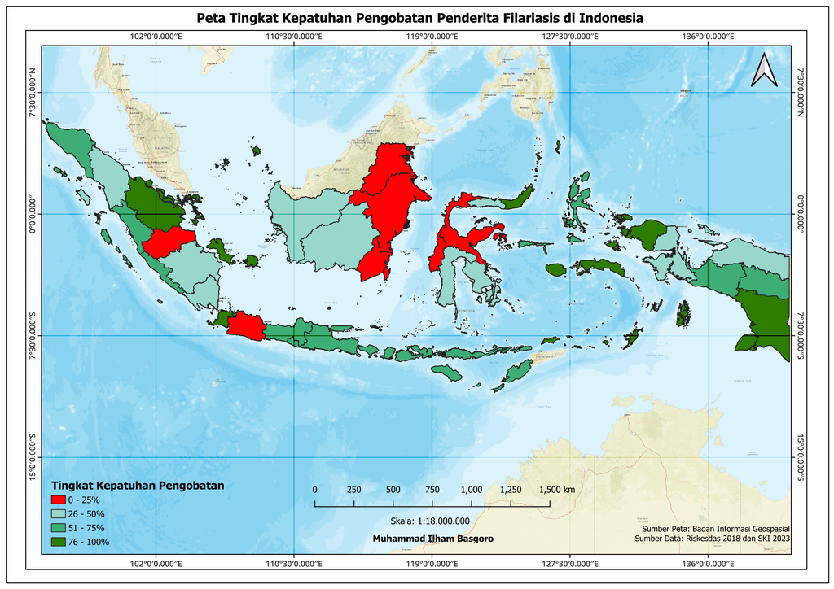